# Cardio Good Fitness

### Split the data set into per product data set

```python
# Split the data set by per product
df_TM798 = df[df.Product=='TM798']
df_TM195 = df[df.Product=='TM195']
df_TM498 = df[df.Product=='TM498']
```

**Product TM195**

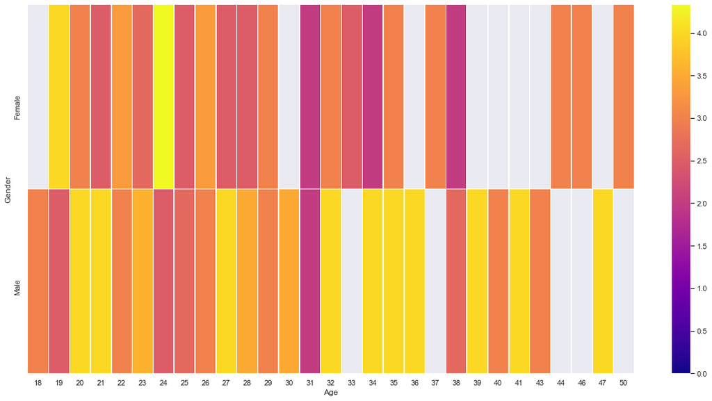

```python
df_hm =df_TM195.pivot_table(index = 'Gender',columns ='Age',values ='Usage')
# Draw a heatmap
plt.figure(figsize = (20,10)) # To resize the plot
sns.heatmap(df_hm,  fmt="d", cmap='plasma', linewidths=.5, vmin=0)
plt.show()
```

**Observations**

- TM195 - Male customers have higher usage of the product.

### Pie Charts

**Pie chart for of Age per product**

```python
# import the needed library for pie plot
from matplotlib.pyplot import pie, axis, show
```

**Age vs Product TM798**

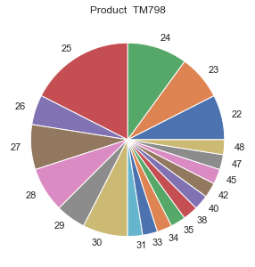

```python
#set the plot size
fig, ax = plt.subplots(figsize=(10, 5), subplot_kw=dict(aspect="equal"))
# Group by to get the count by age
sums = df_TM798.Product.groupby(cardio.Age).count()
# plot the pie chart
ax.pie(sums, labels=sums.index);
# set title for the chart
ax.set_title("Product  TM798")
show()
```

**Observations**

- TM798-Customers in Age 22-30 form the significant group of users

**Age vs Product TM195**

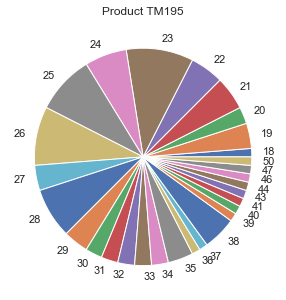

```python
fig, ax = plt.subplots(figsize=(10, 5), subplot_kw=dict(aspect="equal"))
sums = df_TM195.Product.groupby(cardio.Age).count()
ax.pie(sums, labels=sums.index);
ax.set_title("Product TM195")
show()
```

**Observations**

- TM195-Customers in Age 22-29 form the core group of users.

**Age vs Product TM498**

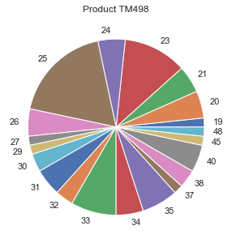

```python
fig, ax = plt.subplots(figsize=(10, 5), subplot_kw=dict(aspect="equal"))
sums = df_TM498.Product.groupby(cardio.Age).count()
ax.pie(sums, labels=sums.index);
ax.set_title("Product TM498")
show()
```

### Group By

**Group by Product and Usage**

```python
dfg = df.groupby(['Product'])['Usage'].mean()
dfg.head()
```

```
Product
TM195    3.087500
TM498    3.066667
TM798    4.775000
Name: Usage, dtype: float64
```

**Observations**

- As observed earlier customer of product TM798 use the product more often.

**Group by Product and Age**

```python
dfg = df.groupby(['Product'])['Age'].mean()
dfg.head()
```

```
Product
TM195    28.55
TM498    28.90
TM798    29.10
Name: Age, dtype: float64
```

**Observations**

- The mean age is almost the same for all products.

### Pandas Profiling

```python
from pandas_profiling import ProfileReport
# Use the original dataframe, so that original features are considered
prof = ProfileReport(data)
# to view report created by pandas profile
prof
```

[interactive chart not shown]

**Observations from Pandas Profile Report**

- Total Number of variables in sample.
- Toral Number of observations 180.
- There is no missing data.
- Three unique products.
- Mean Age from observations is 29.
- Average number of usages per week of the products is 3.
- Most observations have a fitness level of 3.
- Average miles run per week is 103.2 .

# **Conclusion and Recommendations**

## Conclusion

Dataset of 180 observation was analysed. This data contained the usage characteristics of the customer across three different products. Product TM195 had the most observations. The key feature will be usage per week. Also related are Fitness level and miles expected to run per week as these two feature (Fitness level and miles per week) will influence the usage.

We can summarize that:

1. Most customers have TM195 product.
2. There are more male customer than female customers.
3. There are more customers who are with Marital Status of Partnered.
4. Customers between 24 to 33 are more likely to use the product
5. TM195 & TM498, have a similar customer profile regarding usage level, Age, income and miles run per week
   - Usage per week: 3
   - Gender: Males
   - Fitness level: 3
   - Miles run per week: 50 -100
   - Annual Income: 40000 to 60000
   - Education: 14 to 16 years
   - Age: 23-28
6. TM798's customer profile:
   - Usage per week: 4
   - Gender: Males
   - Fitness level: 5
   - Miles run per week: 100
   - Annual Income: Above 60000
   - Education: More than 16 years
   - Age: 22-30

## Recommendation to business

1. Age group of 24 -33 form the core group of customers.
2. TM798 is more popular among Male customers.
3. TM798 is more popular with customer desiring a higher fitness level and having higher income.
4. TM195 is the most popular product.

## Further Analysis

1. TM798 has a different customer profile from the other two, more data needs to be collected to analyse this.